# Predictive Model for Customer Churn: A Case Study in Banking

### Objective

To develop a model/method for identifying customers who are likely to exit

### Background:

Bank customer churn, also known as customer attrition, refers to the phenomenon where customers stop doing business with a bank or switch to another bank. Churn is a critical metric for banks as it directly impacts their customer base and revenue. The dataset represents bank customer information for churn analysis. Each row in the dataset corresponds to a specific customer and contains several features or attributes that describe them.  
While we have worked with BLR, Naive Bayes, and SVM in earlier case study, we will be using tree methods in this one.

### Import Libraries

```r
library(dplyr)
library(caret)
library(ROCR)
library(e1071)
library(car)
library(partykit)
library(randomForest)
```

### Import Data

```r
data <- read.csv('Bank Churn.csv')
head(data)
```

```
  RowNumber CustomerId  Surname CreditScore Geography Gender Age Tenure
1         1   15634602 Hargrave         619    France Female  42      2
2         2   15647311     Hill         608     Spain Female  41      1
3         3   15619304     Onio         502    France Female  42      8
4         4   15701354     Boni         699    France Female  39      1
5         5   15737888 Mitchell         850     Spain Female  43      2
6         6   15574012      Chu         645     Spain   Male  44      8
    Balance NumOfProducts HasCrCard IsActiveMember EstimatedSalary Exited
1      0.00             1         1              1       101348.88      1
2  83807.86             1         0              1       112542.58      0
3 159660.80             3         1              0       113931.57      1
4      0.00             2         0              0        93826.63      0
5 125510.82             1         1              1        79084.10      0
6 113755.78             2         1              0       149756.71      1
```

### Data Description

| Field | Description |
| --- | --- |
| CustomerId | Customer identifiers |
| Surname | Surname of Customer |
| CreditScore | Creditworthiness score of customers |
| Geography | Country name |
| Gender | Gender of customer |
| Age | Age of customer |
| Tenure | Duration of customer engagement or membership |
| Balance | Amount of funds held in customer accounts |
| NumOfProducts | Number of products or services owned by customers |
| HasCrCard | Whether customers possess a credit card or not |
| IsActiveMember | Whether customers are active member of loyalty program |
| EstimatedSalary | The approximate salary of customers |
| Exited | Whether customers have churned or exited the service |

### Converting data types (Required for modelling)

```r
data <- data %>%
  mutate_at(vars(c('HasCrCard','IsActiveMember','Exited',"Geography", "Gender")), ~as.factor(.))
```

### Splitting Data into Train and Test data sets

```r
index <- createDataPartition(data$Exited, p=0.7, list= F)

traindata <- data[index,]
testdata <- data[-index,]
```

### Estimating the attrition rate

```r
counts  <-data.frame(table(data$Exited))
colnames(counts)[1] <- "Exited"
counts$Percent <- counts$Freq / sum(counts$Freq)
counts
```

```
  Exited Freq Percent
1      0 7963  0.7963
2      1 2037  0.2037
```

Attrition rate for customers is around 20%

### Model 1. Desicion Tree

#### Building Model

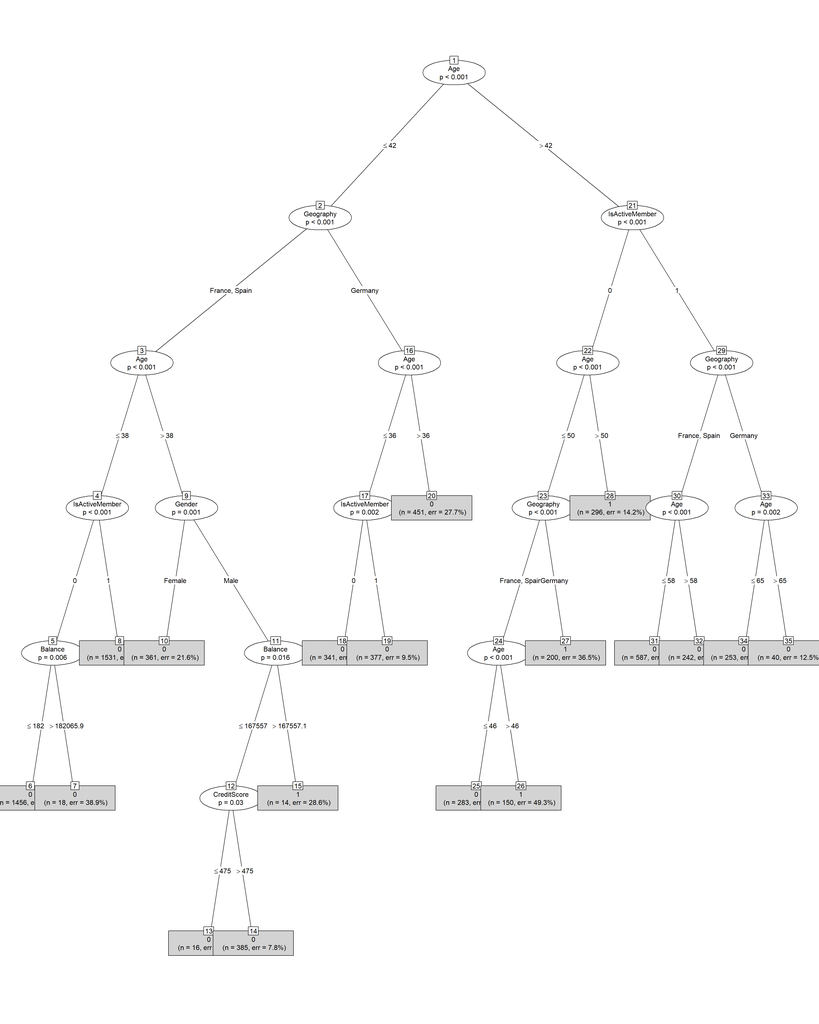

```r
ctree<-partykit::ctree(Exited ~ CreditScore+ Geography + Gender + Age + Tenure + Balance + NumOfProducts+ HasCrCard + IsActiveMember + EstimatedSalary,data = traindata)

plot(ctree,type="simple")
```

#### Multicollinearity

Multicollinearity, which is the high correlation between predictor variables, is generally not a concern for tree-based methods like decision trees, random forests, and gradient boosting machines. These methods are inherently able to handle multicollinearity because they select variables based on how well they split the data at each node, rather than relying on the strength or direction of the relationship between predictors.

In contrast, linear regression, logistic regression, and other linear models can be greatly affected by multicollinearity, as they depend on the inversion of matrices that can become unstable when predictors are highly correlated.

#### ROC Curve and AUC for Test Data

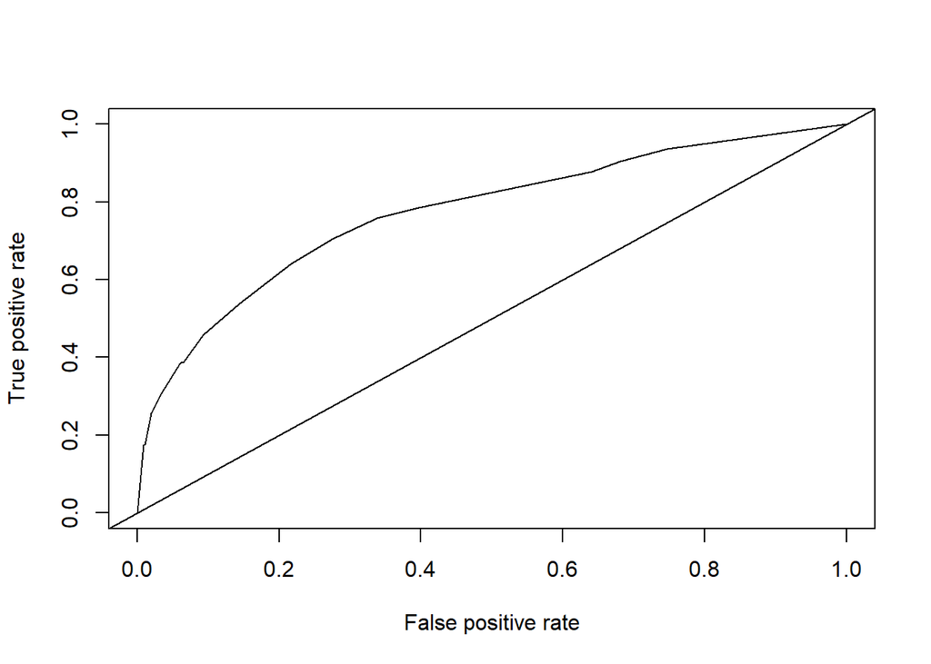

```r
predtree <- predict(ctree,testdata,type="prob")
pred <- prediction(predtree[,2], testdata$Exited)
perf<-performance(pred,"tpr","fpr")
plot(perf)
abline(0,1)
```

```r
## Area under ROC Curve in R (AUC)
auc<-performance(pred,"auc")
auc@y.values
```

```
[[1]]
[1] 0.773173
```

#### Confusion Matrix for Test data

```r
testdata$predY<- predict(ctree,testdata,type="response")
confusionMatrix(testdata$predY,testdata$Exited,positive="1")
```

```
Confusion Matrix and Statistics

          Reference
Prediction    0    1
         0 2306  423
         1   82  188

               Accuracy : 0.8316
                 95% CI : (0.8177, 0.8448)
    No Information Rate : 0.7963
    P-Value [Acc > NIR] : 5.038e-07

                  Kappa : 0.345

 Mcnemar's Test P-Value : < 2.2e-16

            Sensitivity : 0.30769
            Specificity : 0.96566
         Pos Pred Value : 0.69630
         Neg Pred Value : 0.84500
             Prevalence : 0.20373
         Detection Rate : 0.06269
   Detection Prevalence : 0.09003
      Balanced Accuracy : 0.63668

       'Positive' Class : 1
```

#### Comment :

The overall model accuracy is 83%. The area under ROC curve is 77.31

### Model 2. Random forest

##### Building Model

```r
churn_rf<-randomForest(Exited ~ CreditScore+ Geography + Gender + Age + Tenure + Balance + NumOfProducts+ HasCrCard + IsActiveMember + EstimatedSalary, data = traindata, mtry = 3, ntree =100,importance=TRUE)
churn_rf
```

```
Call:
 randomForest(formula = Exited ~ CreditScore + Geography + Gender +      Age + Tenure + Balance + NumOfProducts + HasCrCard + IsActiveMember +      EstimatedSalary, data = traindata, mtry = 3, ntree = 100,      importance = TRUE)
               Type of random forest: classification
                     Number of trees: 100
No. of variables tried at each split: 3

        OOB estimate of  error rate: 13.8%
Confusion matrix:
     0   1 class.error
0 5358 217  0.03892377
1  749 677  0.52524544
```

#### Variable Importance Plot

```r
churn_rf$importance
```

```
                            0            1 MeanDecreaseAccuracy
CreditScore      1.649272e-03 0.0008777055         0.0014961082
Geography       -2.096353e-04 0.0479605303         0.0096488713
Gender           8.753982e-04 0.0044953144         0.0016093526
Age              3.402172e-02 0.1222866149         0.0520331144
Tenure          -8.550078e-05 0.0027132148         0.0005065801
Balance          1.318568e-02 0.0429510860         0.0192978888
NumOfProducts    3.897692e-02 0.1023722014         0.0519272814
HasCrCard       -2.253924e-04 0.0026454927         0.0003622909
IsActiveMember   1.624645e-02 0.0296979507         0.0190011092
EstimatedSalary  1.451734e-04 0.0002589019         0.0001814574
                MeanDecreaseGini
CreditScore            308.77576
Geography               89.92035
Gender                  40.27475
Age                    529.27726
Tenure                 168.02892
Balance                316.29541
NumOfProducts          284.06923
HasCrCard               36.36419
IsActiveMember          93.88201
EstimatedSalary        312.82226
```

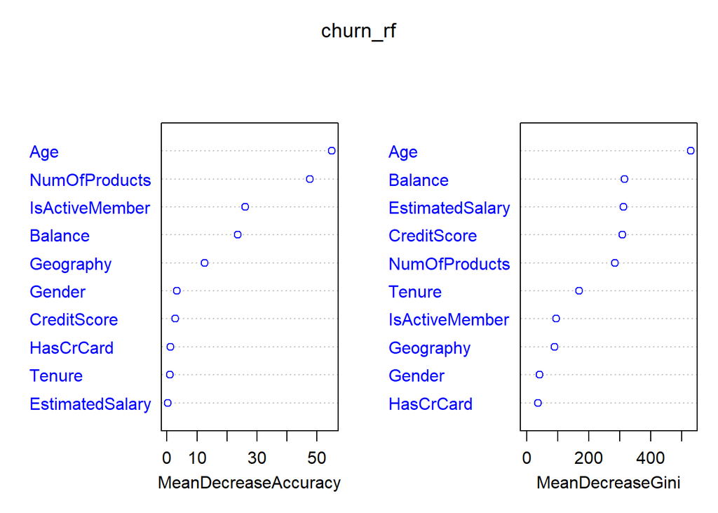

```r
varImpPlot(churn_rf,col="blue")
```

#### ROC Curve and AUC for Test Data

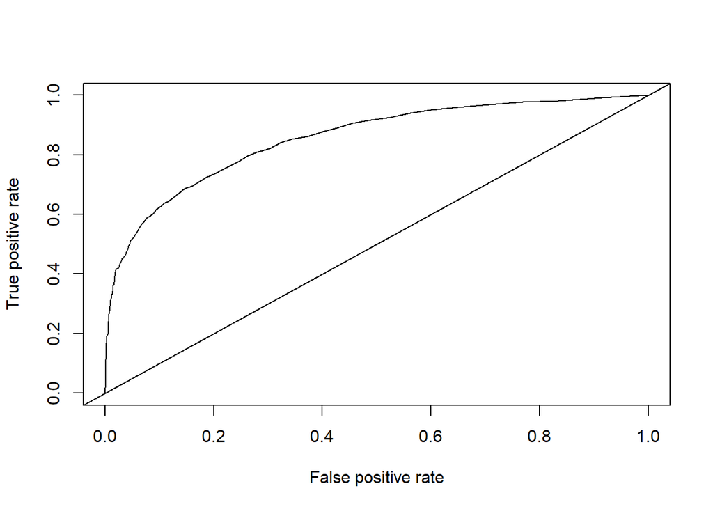

```r
predrf <- predict(churn_rf,testdata, type = "vote", norm.votes = TRUE)

pred<-prediction(predrf[,2],testdata$Exited)
perf<-performance(pred,"tpr","fpr")
plot(perf)
abline(0,1)
```

```r
auc<-performance(pred,"auc")
auc@y.values
```

```
[[1]]
[1] 0.8551915
```

#### Confusion Matrix for test data

```r
testdata$predY<- predict(churn_rf,testdata,type="response")
confusionMatrix(testdata$predY,testdata$Exited,positive="1")
```

```
Confusion Matrix and Statistics

          Reference
Prediction    0    1
         0 2307  332
         1   81  279

               Accuracy : 0.8623
                 95% CI : (0.8494, 0.8744)
    No Information Rate : 0.7963
    P-Value [Acc > NIR] : < 2.2e-16

                  Kappa : 0.499

 Mcnemar's Test P-Value : < 2.2e-16

            Sensitivity : 0.45663
            Specificity : 0.96608
         Pos Pred Value : 0.77500
         Neg Pred Value : 0.87419
             Prevalence : 0.20373
         Detection Rate : 0.09303
   Detection Prevalence : 0.12004
      Balanced Accuracy : 0.71135

       'Positive' Class : 1
```

##### Observation:

The overall model accuracy is 86%. The area under ROC curve is 85.52

#### Conclusion:

The Random forest method gives higher AUC for test data when compared with Decision tree.